# Text mining the Bible

```r
library(readr)
library(tm)
```

```r
library(wordcloud)
library(sentimentr)
library(reshape2)
library(ggplot2)
library(dplyr)
library(tidyr)
setwd('C:/Users/Dean/Desktop/University of Idaho/Classes/Fall 2018/STAT 517/Stat517-master/Data')
ASV = read.csv("C:/Users/Dean/Desktop/University of Idaho/Classes/Fall 2018/STAT 517/Stat517-master/Data/bible_asv.csv", sep = ',', header=T)


dim(ASV)
```

```
## [1] 31103     8
```

```r
head(ASV)
```

|  | doc_id | field | Testaments | Sections | Books | Chapters | Verses | text |
| --- | --- | --- | --- | --- | --- | --- | --- | --- |
| 1 | 1 | 1001001 | OT | Law | gen | gen_1 | gen_1:1 | In the beginning God created the heavens and the earth. |
| 2 | 2 | 1001002 | OT | Law | gen | gen_1 | gen_1:2 | And the earth was waste and void; and darkness was upon the face of the deep: and the Spirit of God moved upon the face of the waters. |
| 3 | 3 | 1001003 | OT | Law | gen | gen_1 | gen_1:3 | And God said, Let there be light: and there was light. |
| 4 | 4 | 1001004 | OT | Law | gen | gen_1 | gen_1:4 | And God saw the light, that it was good: and God divided the light from the darkness. |
| 5 | 5 | 1001005 | OT | Law | gen | gen_1 | gen_1:5 | And God called the light Day, and the darkness he called Night. And there was evening and there was morning, one day. |
| 6 | 6 | 1001006 | OT | Law | gen | gen_1 | gen_1:6 | And God said, Let there be a firmament in the midst of the waters, and let it divide the waters from the waters. |

```r
attach(ASV)

text.Book=c()
for (i in 1:66) {
  text.Book[i]=paste(text[Books==as.character(unique(Books)[i])],collapse = " ")
}

ASV_Books=data.frame(Books=unique(Books),Testaments=as.factor(c(rep("OT",39),rep("NT",27))),
                     Sections=as.factor(c(rep("Law",5),rep("History",12),rep("Wisdom",5),rep("Prophets",17),rep("Gospels",5),rep("Paul",13),rep("Apostles",9))),
                     text=text.Book,
                     doc_id=as.factor(1:66))
attach(ASV_Books)
dim(ASV_Books)
```

```
## [1] 66  5
```

```r
head(ASV_Books)
```

|  | Books | Testaments | Sections | text | doc_id |
| --- | --- | --- | --- | --- | --- |
| 1 | gen | OT | Law | In the beginning God created the heavens and the earth. And the earth was waste and void; and darkness was upon the face of the deep: and the Spirit of God moved upon the face of the waters. And God s… | 1 |
| 2 | exod | OT | Law | Now these are the names of the sons of Israel, who came into Egypt (every man and his household came with Jacob): Reuben, Simeon, Levi, and Judah, Issachar, Zebulun, and Benjamin, Dan and Naphtali, Ga… | 2 |
| 3 | lev | OT | Law | And Jehovah called unto Moses, and spake unto him out of the tent of meeting, saying, Speak unto the children of Israel, and say unto them, When any man of you offereth an oblation unto Jehovah, ye sh… | 3 |
| 4 | num | OT | Law | And Jehovah spake unto Moses in the wilderness of Sinai, in the tent of meeting, on the first day of the second month, in the second year after they were come out of the land of Egypt, saying, Take ye… | 4 |
| 5 | deut | OT | Law | These are the words which Moses spake unto all Israel beyond the Jordan in the wilderness, in the Arabah over against Suph, between Paran, and Tophel, and Laban, and Hazeroth, and Di-zahab. It is elev… | 5 |
| 6 | josh | OT | History | Now it came to pass after the death of Moses the servant of Jehovah, that Jehovah spake unto Joshua the son of Nun, Moses' minister, saying, Moses my servant is dead; now therefore arise, go over this… | 6 |

There are a total of 66 books in the bible, with 39 in the old testament and 27 in the new testament. There are also 7 sections, Law, History, Wisodom, Prophets, Gospels, Paul, and Apostles. We are going to use this data set to do text mining and a cluster analysis to see how these books group with unsupervised learning techniques.

```r
library(tm)
corpus = Corpus(DataframeSource(ASV_Books))
corpus
```

```
## <<SimpleCorpus>>
## Metadata:  corpus specific: 1, document level (indexed): 3
## Content:  documents: 66
```

We need to complete some preprocessing such as making all letters lowercase letters, removing spaces, removing punctuation and removing numbers.

```r
N<-tm_map(corpus, stripWhitespace)
N <- tm_map(N, content_transformer(tolower))
tm_map(N, stemDocument)
```

```
## <<SimpleCorpus>>
## Metadata:  corpus specific: 1, document level (indexed): 3
## Content:  documents: 66
```

```r
DTM <- DocumentTermMatrix(N)

DTM
```

```
## <<DocumentTermMatrix (documents: 66, terms: 12315)>>
## Non-/sparse entries: 76321/736469
## Sparsity           : 91%
## Maximal term length: 16
## Weighting          : term frequency (tf)
```

```r
dim(DTM)
```

```
## [1]    66 12315
```

```r
library(slam)
freqs <- col_sums(DTM)
words <- colnames(DTM)
wordlist <- data.frame(words, freqs)
wordIndexes <- order(wordlist[, "freqs"], decreasing = TRUE)
wordlist <- wordlist[wordIndexes, ]
head(wordlist, 50)
```

|  | words | freqs |
| --- | --- | --- |
| the | the | 59141 |
| and | and | 52094 |
| that | that | 13576 |
| unto | unto | 9257 |
| for | for | 9170 |
| shall | shall | 9105 |
| his | his | 8151 |
| they | they | 7592 |
| jehovah | jehovah | 6888 |
| him | him | 6609 |

[output cut: 40 more lines]

Here is a list of the 50 most frequent words in the entire bible, some of these may not help with our analysis so we will remove them later on.

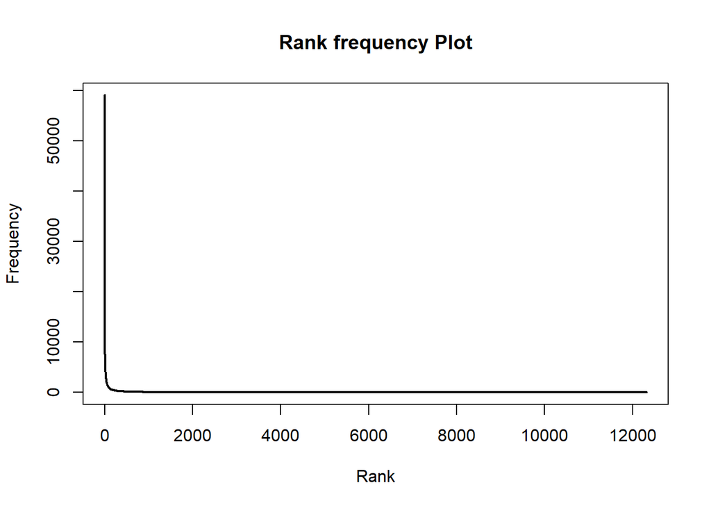

```r
plot(wordlist$freqs , type = "l", lwd=2, main = "Rank frequency Plot", xlab="Rank", ylab ="Frequency")
```

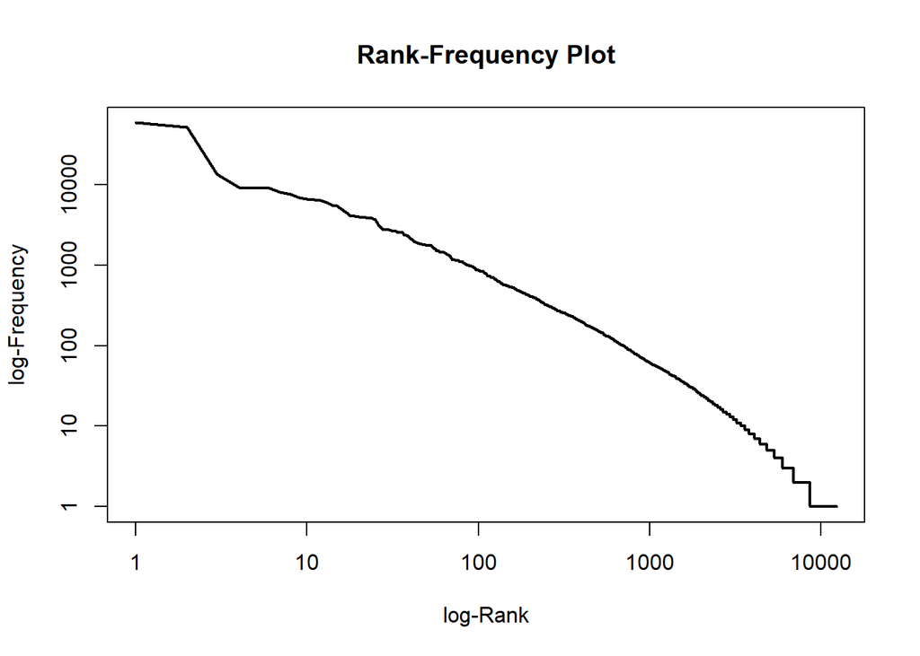

```r
plot(wordlist$freqs , type = "l", log="xy", lwd=2, main = "Rank-Frequency Plot", xlab="log-Rank", ylab ="log-Frequency")
```

```r
ASV_Books$doc_id <- ASV_Books$Books
myCorpus <- Corpus(DataframeSource(ASV_Books))
myCorpus = tm_map(myCorpus, content_transformer(tolower))
myCorpus = tm_map(myCorpus, removePunctuation)
myCorpus = tm_map(myCorpus, removeNumbers)
```

```r
removed = c("thou", "thee", "thy", "hath", "hast", "saith", "shal", "thine", "the", "and", "unto", "for", "his", "that")

myCorpus = tm_map(myCorpus, removeWords,c(stopwords("english"),

                              stopwords('SMART'), removed))



myDtm = TermDocumentMatrix(myCorpus,

                           control = list(minWordLength = 1))
```

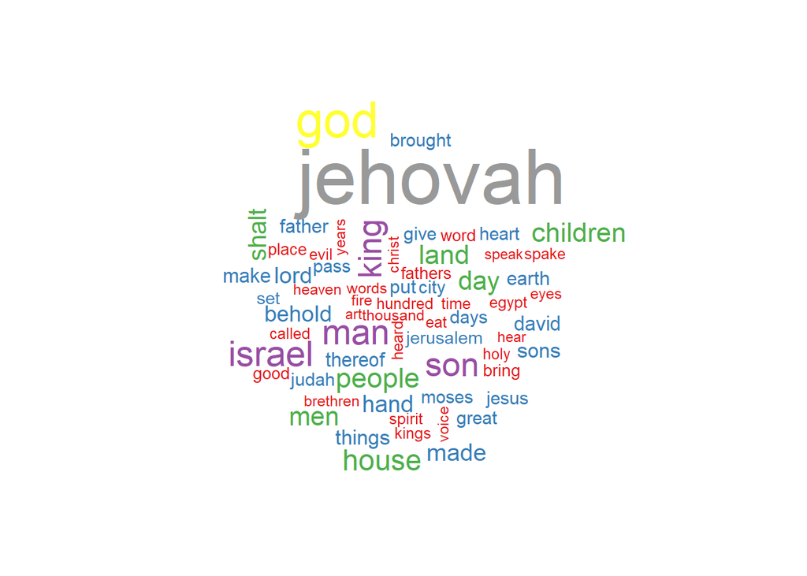

```r
m <- as.matrix(myDtm)
v <- sort(rowSums(m), decreasing=TRUE)
myNames <- names(v)
d <- data.frame(word=myNames, freq=v)
wctop <-wordcloud(d$word, d$freq, min.freq=500, colors=brewer.pal(9,"Set1"))
```

Here is a word cloud of the entire bible with all 66 books. Clearly “god” and “Jehovah” are the two most frequent words in all books.

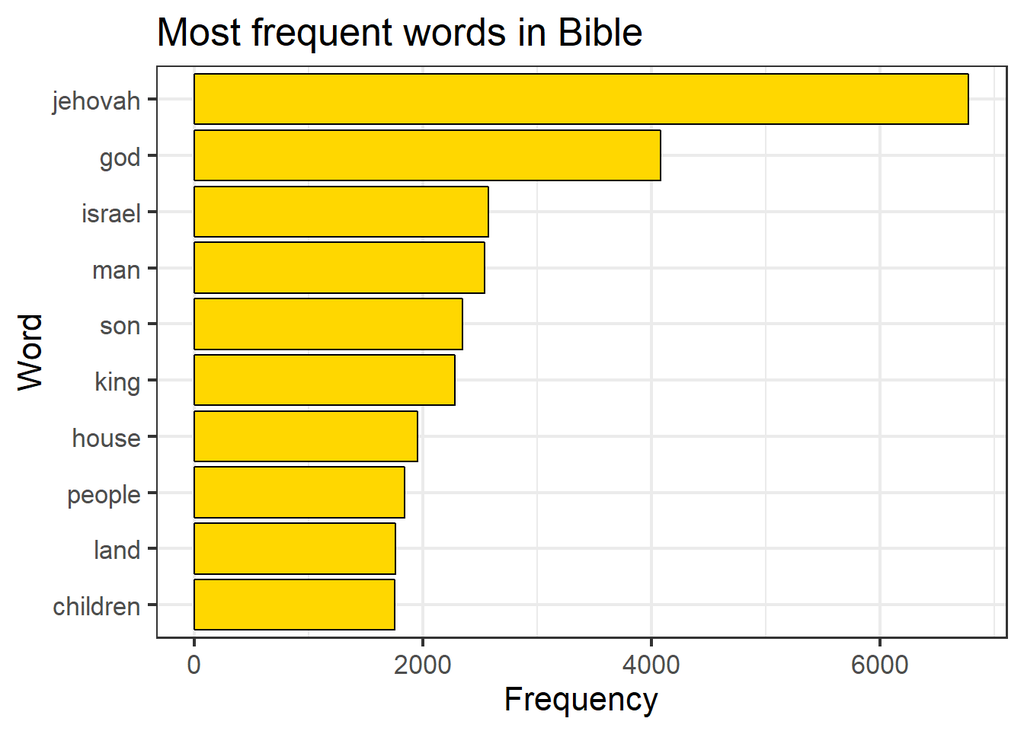

```r
ggplot(d[1:10,], aes(x=reorder(word,freq), y=freq)) +
  geom_bar(stat="identity", fill="gold", colour="black") +
  coord_flip() + theme_bw(base_size = 16) +
  labs(title="Most frequent words in Bible", x="Word", y="Frequency")
```

Here is another plot showing the word frequency.

```r
library(mclust)
library(NbClust)
library(textmineR)
dtm <- CreateDtm(doc_vec = ASV_Books$text, # character vector of documents
                 doc_names = ASV_Books$Books, # document names
                 ngram_window = c(1, 10), # minimum and maximum n-gram length
                 stopword_vec = c(tm::stopwords("english"), # stopwords from tm
                                  tm::stopwords("SMART")), # this is the default value
                 lower = TRUE, # lowercase - this is the default value
                 remove_punctuation = TRUE, # punctuation - this is the default
                 remove_numbers = TRUE, # numbers - this is the default
                 verbose = FALSE, # Turn off status bar for this demo
                 cpus = 2) # default is all available cpus on the system

tf_mat <- TermDocFreq(dtm)
```

```r
tfidf <- t(dtm[ , tf_mat$term ]) * tf_mat$idf
tfidf <- t(tfidf)
csim <- tfidf / sqrt(rowSums(tfidf * tfidf))
csim <- csim %*% t(csim)
cdist <- as.dist(1 - csim)
```